# Computer Repair Times Dataset

### Step 1: Import modules

```python
import math
import numpy as np
import pandas as pd
import seaborn as sb
import statistics as st
import matplotlib.pyplot as plt
import plotly.express as px
from scipy.stats import kurtosis
from scipy.stats import skew
```

### Step 2: Read data from the dataset and initialize it

```python
cpt_data = pd.read_csv('resources/Computer_Repair_Time.csv')
cpt = cpt_data["RepairTime"]
# Display the first 5 rows of the dataset
cpt_data.head()
```

|  | Sample | RepairTime |
| --- | --- | --- |
| 0 | 1 | 18 |
| 1 | 2 | 15 |
| 2 | 3 | 17 |
| 3 | 4 | 9 |
| 4 | 5 | 37 |

### Step 3: Calculate the meaning of values

Meaning of values: Mean, Median, Mode, Quantile, Variance, Standard Deviation, Skewness, Kurtosis.

#### 3.1. Mean

Formula: $$ \bar{x\ }=\frac{\sum_{i=1}^{n}x_i}{n} $$

##### 3.1.1. With formula

```python
mean_cpt = sum(cpt) / len(cpt)
mean_cpt
```

```
14.912
```

##### 3.1.2. With .mean() funciton

```python
# With statistics library
mean_cpt_st = st.mean(cpt)
mean_cpt_st
```

```
14.912
```

#### 3.2. Median

To find the median of a set of numbers, follow these steps:

- Arrange the numbers in ascending (increasing) order from smallest to largest.
- If the number of values is odd, the median is the middle value. For example, if the numbers are: 5, 7, 9, 12, or 15 The median is 9 (the middle value)
- If the number of values is even, the median is the average of the two middle values. For example, if the numbers are: 4, 6, 8, 10, 12, 14 The two middle values are 8 and 10. The median is (8 + 10) / 2 = 9

##### 3.2.1. Without using library

```python
# Sort the data in ascending order with bubble sort algorithm
for i in range (0, len(cpt)):
    for j in range (i+1, len(cpt)):
        if cpt[i] > cpt[j]:
            cpt[i], cpt[j] = cpt[j], cpt[i]

# Check length of the list to determine if it is even or odd
if len(cpt) % 2 == 0:
    median_cpt = (cpt[len(cpt) // 2 - 1] + cpt[len(cpt) // 2]) / 2
else:
    median_cpt = cpt[len(cpt) // 2]

median_cpt
```

```
14.0
```

##### 3.2.2. With .median() function

```python
# with statistics library
median_cpt_st = st.median(cpt)
median_cpt_st
```

```
14.0
```

#### 3.3. Mode

To find the mode, we need to count the occurrences of each value in the dataset. We can create a dictionary where the keys are the unique values, and the values are the corresponding frequencies. The mode is the value(s) that appear most frequently in the dataset. Besides, we can use the .mode() method to solve the mode value.

##### 3.3.1. Without using library

```python
# Count the number of occurences of each value
cpt_occurences = {}
for i in cpt:
    if i in cpt_occurences:
        cpt_occurences[i] += 1
    else:
        cpt_occurences[i] = 1
# Find the value with the highest number of occurences
mode_cpt = max(cpt_occurences, key=cpt_occurences.get)
mode_cpt
```

```
12
```

##### 3.3.2. With .mode() function

```python
# with statistics library
mode_cpt_st = st.mode(cpt)
mode_cpt_st
```

```
12
```

#### 3.4. Quantile

In this case, the values that divide the dataset into four equal parts. The first quartile (Q1) is the 25th percentile, the second quartile (Q2) is the 50th percentile (same as the median), and the third quartile (Q3) is the 75th percentile. In the numpy library, we can call the command .quantitle(). This command needs the quantile value to compute.

##### 3.4.1. Without using library

```python
# Sort the data in ascending order with bubble sort algorithm
for i in range (0, len(cpt)):
    for j in range (i+1, len(cpt)):
        if cpt[i] > cpt[j]:
            cpt[i], cpt[j] = cpt[j], cpt[i]
# Find the range
q1_cpt = cpt[int(len(cpt) * 0.25)]
q2_cpt = cpt[int(len(cpt) * 0.5)]
q3_cpt = cpt[int(len(cpt) * 0.75)]
print("Q1: ", q1_cpt)
print("Q2: ", q2_cpt)
print("Q3: ", q3_cpt)
```

```
Q1:  11
Q2:  14
Q3:  17
```

##### 3.4.2. With .quantile() function

```python
# with numpy library
q1_cpt_np = np.quantile(cpt, 0.25)
q2_cpt_np = np.quantile(cpt, 0.5)
q3_cpt_np = np.quantile(cpt, 0.75)
print("Q1: ", q1_cpt_np)
print("Q2: ", q2_cpt_np)
print("Q3: ", q3_cpt_np)
```

```
Q1:  11.0
Q2:  14.0
Q3:  17.0
```

#### 3.5. Variance

Formula: $$ s^2=\frac{\sum_{i=1}^{n}{(x_i\ -\ \bar{x})}^2}{n\ -\ 1} $$

##### 3.5.1. Without using library

```python
variance_cpt = sum((i - mean_cpt) ** 2 for i in cpt) / (len(cpt) - 1)
variance_cpt
```

```
35.50226506024097
```

##### 3.5.2. With .variance() function

```python
# with statistics library
variance_cpt_st = st.variance(cpt)
variance_cpt_st
```

```
35.502265060240966
```

#### 3.6. Standard deviation

Formula: $$ s=\sqrt{s^2}=\sqrt{\frac{\sum_{i=1}^{n}{(x_i\ -\ \bar{x})}^2}{n\ -\ 1}} $$

##### 3.6.1. With square root of the variance

```python
# with math library
std_cpt = math.sqrt(variance_cpt_st)
std_cpt
```

```
5.958377720507568
```

##### 3.6.2. With .stdv() function

```python
std_cpt_st = st.stdev(cpt)
std_cpt_st
```

```
5.958377720507568
```

#### 3.7. Skewness

Formula: $$ CS=\ \frac{\frac{1}{N}\sum_{i=1}^{n}{(x_{i\ }-\ \mu)}^3}{\sigma^3} =\ \frac{n}{(n - 1)(n - 2)}(\frac{\sum_{i=1}^{n}{(x_{i\ }-\ \bar{x})}}{s})^3 $$

##### 3.7.1. Without using library

```python
skew_cpt = (len(cpt)/((len(cpt)-1)*(len(cpt)-2))) * sum((i - mean_cpt) ** 3 for i in cpt) / (std_cpt ** 3)
skew_cpt
```

```
1.695275575309531
```

##### 3.7.2. With skew() function

```python
# with scipy library
skew_cpt_sc = skew(cpt, bias = False)
skew_cpt_sc
```

```
1.6952755753095303
```

#### 3.8. Kurtosis

Formula: $$ CS=\ \frac{\frac{1}{N}\sum_{i=1}^{n}{(x_{i\ }-\ \mu)}^4}{\sigma^4} =\ \frac{n(n + 1)}{(n - 1)(n - 2)(n - 3)}(\frac{\sum_{i=1}^{n}{(x_{i\ }-\ \bar{x})}}{s})^4 $$

```python
# with scipy library
kurtosis_cpt_sc = kurtosis(cpt)
kurtosis_cpt_sc_not_bias = kurtosis(cpt, bias = False)
print("Kurtosis: ", kurtosis_cpt_sc)
print("Kurtosis without bias (like traditional formula): ", kurtosis_cpt_sc_not_bias)
```

```
Kurtosis:  3.9739941108050942
Kurtosis without bias (like traditional formula):  4.079023408828646
```

### Step 4: Data visualization

#### Histogram

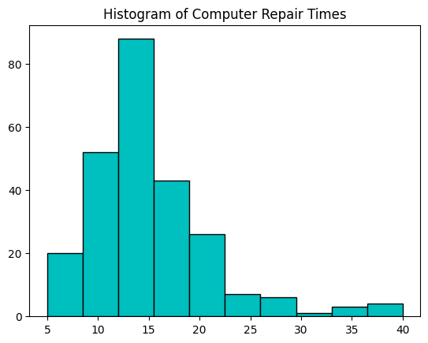

```python
plt.hist(cpt, color='c', edgecolor='k')
plt.title('Histogram of Computer Repair Times')
plt.show()
```

#### Boxplot

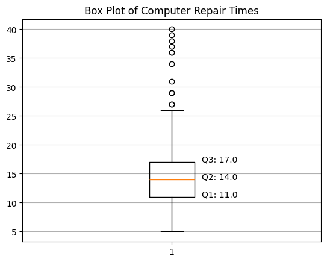

```python
plt.boxplot(cpt, vert=True)
plt.grid(axis='y')
plt.text(1.1, q1_cpt_np, f'Q1: {q1_cpt_np}')
plt.text(1.1, q2_cpt_np, f'Q2: {q2_cpt_np}')
plt.text(1.1, q3_cpt_np, f'Q3: {q3_cpt_np}')
plt.title('Box Plot of Computer Repair Times')
plt.show()
```